# Scraping table data

Pablo Barbera

January 22, 2016

### Scraping web data in table format

We will start by loading the `rvest` package, which will help us scrape data from the web.

```r
#install.packages("rvest")
library(rvest)
```

The goal of this exercise is to scrape the population data from the Census website, and then clean it so that we can generate a population pyramid.

The first step is to read the html code from the website we want to scrape, using the `read_html()` function. If we want to see the html in text format, we can then use `html_text()`.

```r
url <- paste("http://www.census.gov/population/international/data/idb/",
    "region.php?N=%20Results%20&T=10&A=separate&RT=0&Y=2016&R=-1&C=US",
    sep="")
html <- read_html(url) # reading the html code into memory
html # not very informative
```

```
## {xml_document}
## <html>
## [1] <head>&#13;\n\t\t\t<meta name="DESCRIPTION" content="International D ...
## [2] <body onload="hide_region_tables_region(); SelectedReport();">\n\t\t ...
```

```r
substr(html_text(html), 1, 1000) # first 1000 characters
```

```
## [1] "\r\n\r\n\t\t\t\n\t\t\n\t\t\n\t\t\n\t\t\n\t\t\n\t\t\n\t\t\n\t\t\n\t\t\n\t\t\n    \n\t\t\t<!--\n\t\t\t@media print {\n\t\t\t.query_source {page-break-after:always;}\n\t\t\t.noprint {display:none; }\n\t\t\t}\n\t\t\t-->\n\t\t\n        \n\t\t$(document).ready(function() {\n\t\t\t$('.download').cl…
```

To extract all the tables in the html code automatically, we use `html_table()`. Note that it returns a list of data frames, so in order to work with this dataset, we will have to subset the first element of this list.

```r
tab <- html_table(html)
str(tab)
```

```
## List of 1
##  $ :'data.frame':    22 obs. of  9 variables:
##   ..$ Year                 : int [1:22] 2016 2016 2016 2016 2016 2016 2016 2016 2016 2016 ...
##   ..$ Age                  : chr [1:22] "Total" "0-4" "5-9" "10-14" ...
##   ..$ Both Sexes Population: chr [1:22] "323,995,528" "20,038,560" "20,403,263" "20,595,524" ...
##   ..$ Male Population      : chr [1:22] "159,690,758" "10,248,131" "10,417,020" "10,517,509" ...
##   ..$ Female Population    : chr [1:22] "164,304,770" "9,790,429" "9,986,243" "10,078,015" ...
##   ..$ Percent Both Sexes   : num [1:22] 100 6.2 6.3 6.4 6.5 6.9 7.1 6.7 6.4 6.1 ...
##   ..$ Percent Male         : num [1:22] 100 6.4 6.5 6.6 6.8 7.2 7.3 6.9 6.5 6.1 ...
##   ..$ Percent Female       : num [1:22] 100 6 6.1 6.1 6.3 6.6 6.9 6.6 6.3 6 ...
##   ..$ Sex Ratio            : num [1:22] 97.2 104.7 104.3 104.4 104.7 ...
```

```r
pop <- tab[[1]]
```

Now let’s clean the data so that we can use it for our analysis. First, I’ll remove the row with the totals. (Note that I could just do `pop[-1,]`, but imagine that we run this code again one year from now and the format has changed. The approach below is more robust to such changes.)

```r
pop <- pop[-which(pop$Age=="Total"),]
```

Let’s also change the variable names so that they’re easier to work with. (R doesn’t like variable names with spaces.)

```r
names(pop)[which(names(pop)=="Male Population")] <- "Male"
names(pop)[which(names(pop)=="Female Population")] <- "Female"
```

Finally, the other problem we need to fix is to convert the population values into a numeric format, which requires deleting the commas.

```r
pop$Male <- as.numeric(gsub(",", "", pop$Male))
pop$Female <- as.numeric(gsub(",", "", pop$Female))
```

The data is now clean, but we need to convert it to *long* format if we want to use ggplot2 to generate the population pyramid. The following two approaches are equivalent:

```r
df <- data.frame(
    Age = rep(pop$Age, 2),
    value = c(pop$Male, pop$Female),
    Gender = rep(c("Male", "Female"), each=nrow(pop)))
head(df)
```

```
##     Age    value Gender
## 1   0-4 10248131   Male
## 2   5-9 10417020   Male
## 3 10-14 10517509   Male
## 4 15-19 10813192   Male
## 5 20-24 11547150   Male
## 6 25-29 11725696   Male
```

```r
# using melt() from the reshape package
library(reshape)
df <- melt(pop,
    id.vars="Age", measure.vars=c("Male", "Female"),
    variable_name = "Gender")
```

Finally, we need to make the population value negative for one of the two gender categories so that the population pyramid is properly displayed, and also convert the age variable into a factor so that the ordering of the categories is not alphabetical (default with ggplot2).

```r
df$value[df$Gender=="Male"] <- -df$value[df$Gender=="Male"]
df$Age <- factor(df$Age, levels=pop$Age)
```

Now we’re ready to generate the population pyramid figure!

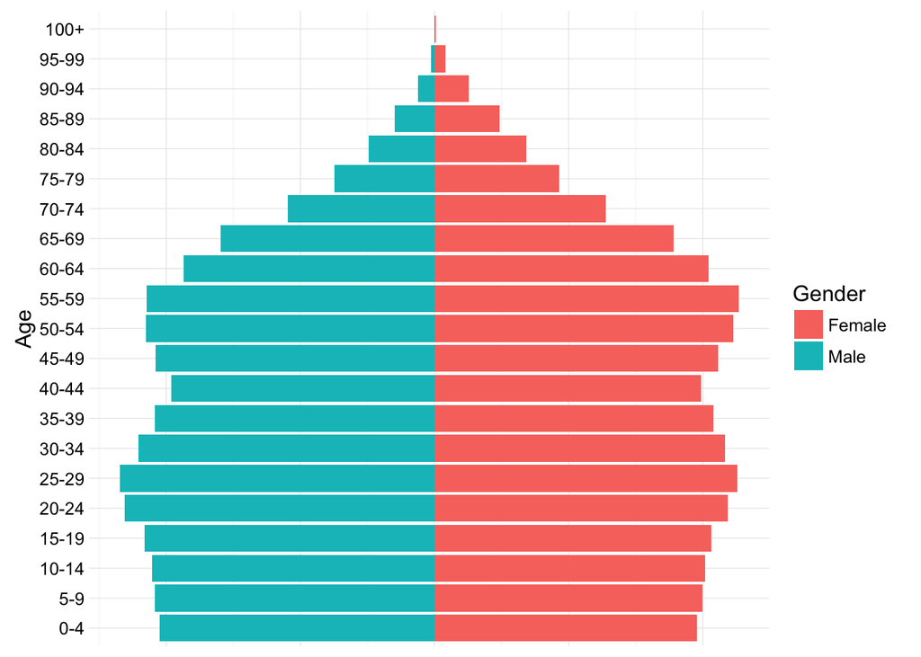

```r
library(ggplot2)
p <- ggplot(df, aes(x=Age, y=value, fill=Gender))
pq <- p + geom_bar(data=df[df$Gender=="Male",], stat="identity") +
    geom_bar(data=df[df$Gender=="Female",], stat="identity") +
    coord_flip() + theme_minimal() +
    theme(axis.title.x=element_blank(), axis.text.x=element_blank())
pq
```

### Scraping web data in table format: a more involved example

When there are multiple tables on the website, scraping them becomes a bit more complicated. Let’s work through a common case scenario: scraping a table from Wikipedia with a list of the most populated cities in the United States.

```r
url <- 'https://en.wikipedia.org/wiki/List_of_United_States_cities_by_population'
html <- read_html(url)
tables <- html_table(html, fill=TRUE)
length(tables)
```

```
## [1] 64
```

The function now returns 64 different tables. I had to use the option `fill=TRUE` because some of the tables appear to have incomplete rows.

In this case, identifying the part of the html code that contains the table is a better approach. To do so, let’s take a look at the source code of the website. In Google Chrome, go to *View* > *Developer* > *View Source*. All browsers should have similar options to view the source code of a website.

In the source code, search for the text of the page (e.g. *2014 rank*). Right above it you will see: `<table class="wikitable sortable" style="text-align:center">`. This is the CSS selector that contains the table. (You can also find this information by right-clicking anywhere on the table, and choosing *Inspect*).

Now that we now what we’re looking for, let’s use `html_nodes()` to identify all the elements of the page that have that CSS class. (Note that we need to use a dot before the name of the class to indicate it’s CSS.)

```r
wiki <- html_nodes(html, '.wikitable')
length(wiki)
```

```
## [1] 6
```

There are 6 tables in total, and we will extract the first one.

```r
pop <- html_table(wiki[[1]])
str(pop)
```

```
## 'data.frame':    297 obs. of  9 variables:
##  $ 2014 rank              : int  1 2 3 4 5 6 7 8 9 10 ...
##  $ City                   : chr  "New York[6]" "Los Angeles" "Chicago" "Houston[7]" ...
##  $ State[5]               : chr  "New York" "California" "Illinois" "Texas" ...
##  $ 2014 estimate          : chr  "8,491,079" "3,928,864" "2,722,389" "2,239,558" ...
##  $ 2010 Census            : chr  "8,175,133" "3,792,621" "2,695,598" "2,100,263" ...
##  $ Change                 : chr  "7000386471999905080♠+3.86%" "7000359231781926010♠+3.59%" "6999993879651194280♠+0.99%" "7000663226462590640♠+6.63%" ...
##  $ 2014 land area         : chr  "7002302600000000000♠302.6 sq mi\n783.8 km2" "7002468700000000000♠468.7 sq mi\n1,213.9 km2" "7002227600000000000♠227.6 sq mi\n589.6 km2" "7002599600000000000♠599.6 sq mi\n1,552.9 km2" ...
##  $ 2010 population density: chr  "7004270120000000000♠27,012 per sq mi\n10,430 km−2" "7003809200000000000♠8,092 per sq mi\n3,124 km−2" "7004118420000000000♠11,842 per sq mi\n4,572 km−2" "7003350100000000000♠3,501 per sq mi\n1,352 km−2" ...
##  $ Location               : chr  "40°39′51″N 73°56′19″W / 40.6643°N 73.9385°W / 40.6643; -73.9385 (1 New York City)" "34°01′10″N 118°24′39″W / 34.0194°N 118.4108°W / 34.0194; -118.4108 (2 Los Angeles)" "41°50′15″N 87°40′54″W / 41.8376°N 87.6818°W / 41.8376; -87.6818 (3 Chicago)" "29°46′50″N 95°23…
```

As in the previous case, we still need to clean the data before we can use it. For this particular example, let’s see if this dataset provides evidence in support of [Zipf’s law for population ranks](https://en.wikipedia.org/wiki/Zipf%27s_law).

We’ll use regular expressions to remove endnotes and commas in the population numbers, and clean the variable names.

```r
pop$City <- gsub('\\[.*\\]', '', pop$City)
pop$population <- as.numeric(gsub(",", "", pop[,"2014 estimate"]))
pop$rank <- pop[,"2014 rank"]
head(pop[,c("City", "population", "rank")])
```

```
##           City population rank
## 1     New York    8491079    1
## 2  Los Angeles    3928864    2
## 3      Chicago    2722389    3
## 4      Houston    2239558    4
## 5 Philadelphia    1560297    5
## 6      Phoenix    1537058    6
```

Now we’re ready to generate the figure:

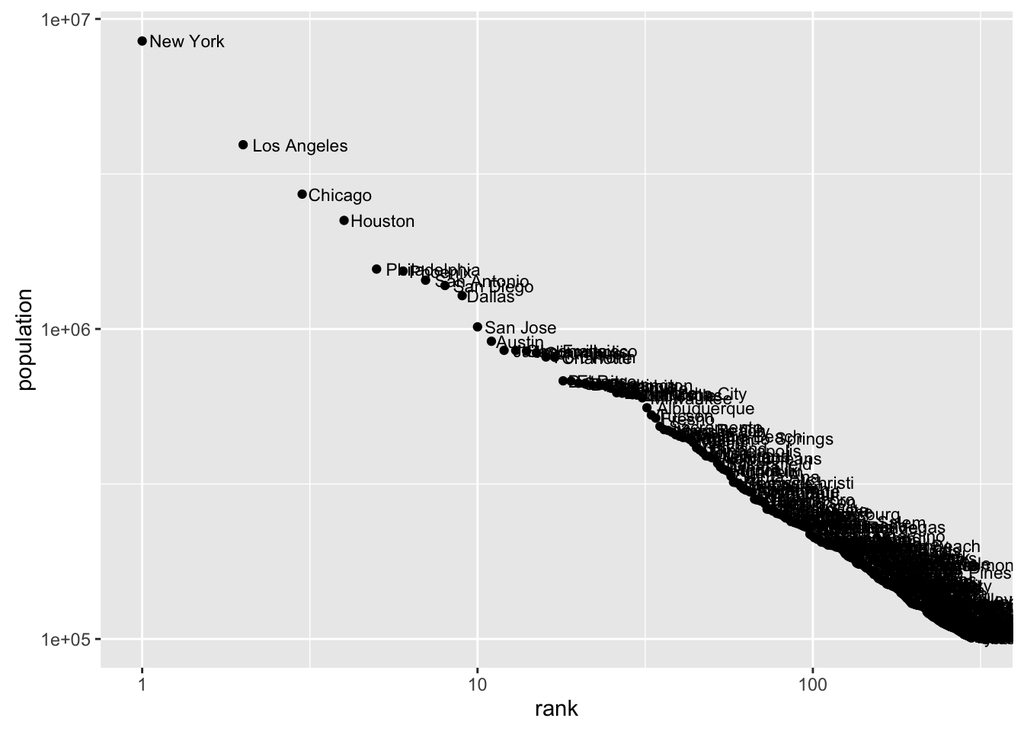

```r
library(ggplot2)
p <- ggplot(pop, aes(x=rank, y=population, label=City))
pq <- p + geom_point() + geom_text(hjust=-.1, size=3) +
    scale_x_log10() + scale_y_log10()
pq
```

We can also check if this distribution follows Zipf’s law estimating a log-log regression.

```r
lm(log(rank) ~ log(population), data=pop)
```

```
##
## Call:
## lm(formula = log(rank) ~ log(population), data = pop)
##
## Coefficients:
##     (Intercept)  log(population)
##          21.408           -1.366
```